# Journal Club

26-08-2020

## Unsupervised protein embeddings outperform hand-crafted sequence and structure features at predicting molecular function

Amelia Villegas-Morcillo, Stavros Makrodimitris, Roeland C.H.J. van Ham, Angel M. Gomez, Victoria Sanchez and Marcel J.T. Reinders

## Introduction

> complex feature representation and deep learning methods outperform hand-crafted features such as one-hot encoding of amino acids, k -mer counts, secondary structure and backbone angles.
- Huge number of protein sequences with unknown function (>175kk in UniProtKB)
- Transfer Learning - ELMo (Embeddings from Language Models) (Peters et al., 2018)
- “Modeling aspects of the language of life through transfer-learning protein sequences.” (Heinzinger, M. et al. (2019))

## Protein representation

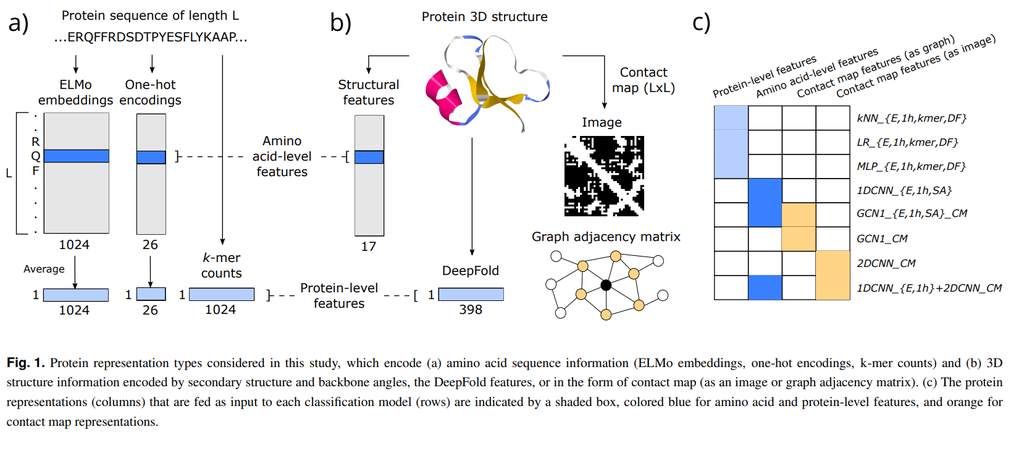

## Models

{E, 1h, kmer, DF}

- k-NN (kNN_*)
- Logistic Regression (LR_*)
- Multi-Layer Perceptron (fully connected NN) (MLP_*)

{E, 1h, SA}

- 1DCNN_*
- GCN1_*_CM

GCN1_CM

2DCNN_CM

1DCNN_{E, 1h} + 2DCNN_CM

## Data

Protein Data Bank

- redundant sequences removed(identity threshold - \(95\%\))
- \(11~749\) protein chains
- \(5\)-fold CV with additional sampling to validation data

SwissProt

- \(80~176\) protein sequences
- train/validation/test split (\(80\%/10\%/10\%\))

CAFA3

## Data

For PDB & SP proteins with sequence length in range \([40, 1000]\) have been considered. These sequences had GO annotations in the Molecular Function Ontology (MFO) with 17 different evidence codes.

## Evaluation metrics

- AUC
- Maximum F-measure (\(F_{max}\)) (harmonic mean of the precision and recall)
- Normalized semantic distance (\(S_{min}\))

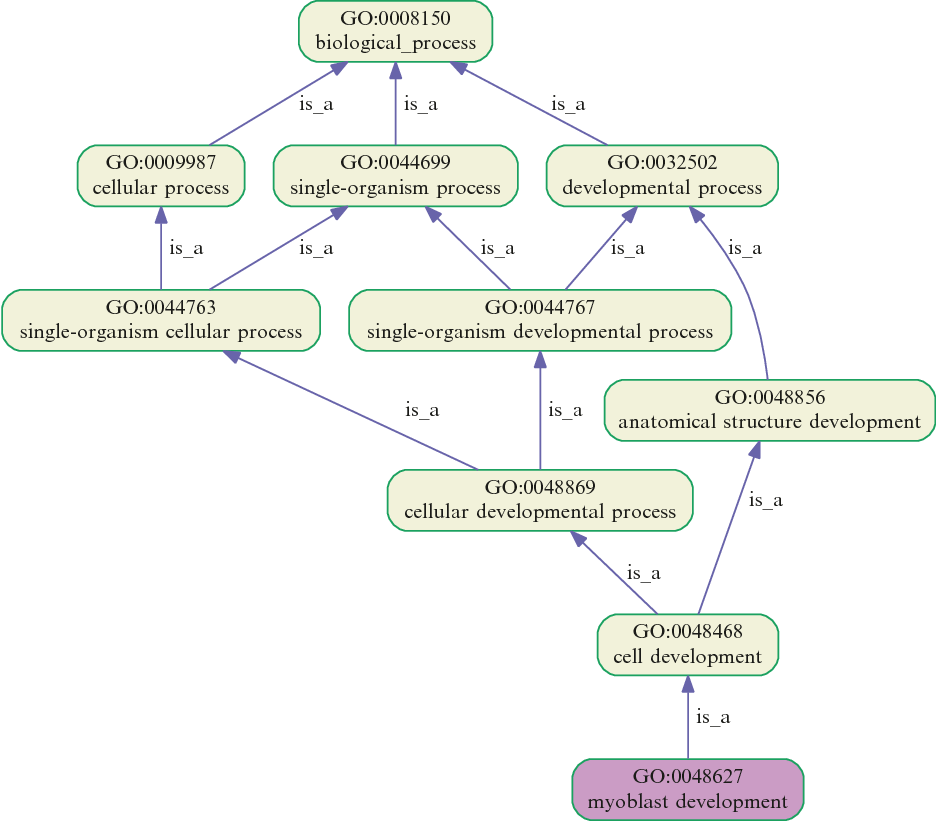

Confidence intervals have been created using Bootstrap.

## Results

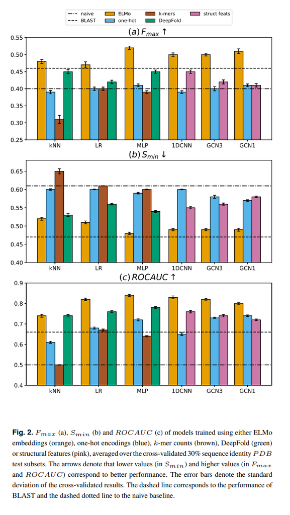

## Results - CAFA

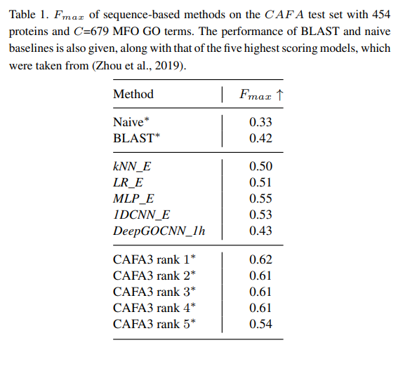